# Modul 05: Eksplorasi Hubungan Dua Peubah & Analisis Korelasi

# 1 Peta Metode Analisis Hubungan Dua Peubah

Setelah membahas perbandingan nilai tengah perlakuan pada perancangan percobaan di Modul 01–04, pada modul ini fokus pembahasan beralih pada cara **mengeksplorasi dan menguji keeratan hubungan (asosiasi) antara dua peubah ($X$ dan $Y$)**.

**Perbedaan Mendasar: Analisis Korelasi vs Analisis Regresi!**

- **Analisis Korelasi (Modul 05)**: Mengukur **arah dan kekuatan keeratan hubungan yang bersifat simetris/setara** antara dua peubah ($r_{XY} = r_{YX}$), tanpa mengharuskan peubah yang satu menjadi penyebab bagi peubah yang lain.
- **Analisis Regresi (Modul 06)**: Memodelkan **hubungan fungsional/sebab-akibat satu arah**, di mana peubah bebas ($X$, prediktor) digunakan untuk menduga atau menjelaskan peubah tak bebas ($Y$, respon).

Pemilihan metode analisis asosiasi ditentukan oleh **skala pengukuran kedua peubah** dan **ada tidaknya pencilan (*outlier*)**:

| Skala Peubah $X$ & $Y$ | Kondisi Data / Pola Hubungan | Metode Analisis yang Tepat |
| --- | --- | --- |
| **Kuantitatif Kontinu vs Kontinu** | Pola hubungan **linier**, sebaran normal bikariat, **bebas *outlier***; menguji $H_0: \rho = 0$. | **Korelasi Momen Hasil-Kali Pearson ($r$)** + Uji-$t$ |
| **Kuantitatif Kontinu vs Kontinu** | Menguji korelasi terhadap suatu **nilai konstanta bukan nol ($H_0: \rho = \rho_0$)** atau membangun selang kepercayaan $\rho$. | **Transformasi $Z$ Fisher ($\text{atanh}$)** |
| **Ordinal / Skor** atau **Kontinu Ber-*Outlier*** | Terdapat **pencilan ekstrem**, hubungan monoton melengkung, atau data berskala peringkat. | **Korelasi Peringkat Spearman ($r_s$)** |
| **Kategorik Nominal/Ordinal vs Kategorik** | Data berupa frekuensi cacahan sel kategori silang ($b \times k$). | **Tabel Kontingensi & Uji Khi-Kuadrat ($\chi^2$)** |

# 2 Analisis 5.1: Scatter Plot & Korelasi Linier Pearson + Uji-$t$ ($H_0: \rho = 0$)

## 2.1 Penjelasan Awal (Konsep Dasar)

**Konsep Dasar — Diagram Pencar (*Scatter Plot*) & Koefisien Korelasi Pearson ($r$):**

Langkah wajib pertama sebelum menghitung korelasi apa pun adalah memetakan pasangan $(X_i, Y_i)$ ke dalam **Diagram Pencar (*Scatter Plot*)**. Mengapa? Karena angka korelasi $r \approx 0$ bisa saja berasal dari dua peubah yang sebenarnya memiliki hubungan kuadratik (parabola sempurna) namun bukan garis lurus!

**Koefisien Korelasi Linier Pearson ($r$)** mengukur derajat keeratan **hubungan garis lurus** dengan nilai berkisar pada $-1 \le r \le +1$: * $r > 0$ (mendekati $+1$): Hubungan linier **positif/searah** yang kuat ($X$ meningkat $\rightarrow$ $Y$ meningkat). * $r < 0$ (mendekati $-1$): Hubungan linier **negatif/berlawanan arah** yang kuat ($X$ meningkat $\rightarrow$ $Y$ menurun). * $r \approx 0$: Tidak terdapat hubungan **linier** antara $X$ dan $Y$.

## 2.2 Konteks Kasus & Kapan Menggunakan Analisis Ini

**Dua Studi Kasus Korelasi Linier Pearson:**

Gunakan **Korelasi Pearson** apabila kedua peubah berskala kuantitatif kontinu (interval/rasio), diagram pencar menunjukkan kecenderungan garis lurus, dan tidak terdapat pencilan ekstrem: 1. **Kasus 1 — Jarak Tempuh vs Emisi Gas Hidrokarbon (`data/10_emisi_hc_korelasi.csv`)**: Pengukuran jarak tempuh kumulatif (ribu km) dan emisi gas buang HC (gram/km) pada $n = 10$ unit kendaraan dalam kondisi mesin normal. 2. **Kasus 2 — Frekuensi Derik Jangkrik vs Suhu Udara (`data/11_jangkrik_suhu.csv`)**: Pengamatan bioakustik entomologi pada $n = 15$ pengamatan mengenai banyaknya derik jangkrik tanah (*striped ground cricket*) per detik dan suhu udara lingkungan (°F).

## 2.3 Rumus Koefisien Korelasi Pearson, Statistik Uji-$t$, & Hipotesis

Koefisien korelasi contoh Pearson ($r$) didefinisikan sebagai rasio peragam (*covariance*) terhadap hasil kali simpangan baku kedua peubah:

$$r = \frac{S_{XY}}{\sqrt{S_{XX} \cdot S_{YY}}} = \frac{\sum_{i=1}^n (X_i - \bar{X})(Y_i - \bar{Y})}{\sqrt{\sum_{i=1}^n (X_i - \bar{X})^2 \sum_{i=1}^n (Y_i - \bar{Y})^2}}$$

Untuk menguji apakah korelasi linier di populasi ($\rho$) berbeda nyata dari nol:

- **$H_0 : \rho = 0$** (Tidak terdapat hubungan linier antara peubah $X$ dan peubah $Y$).
- **$H_1 : \rho \neq 0$** (Terdapat hubungan linier yang nyata antara peubah $X$ dan peubah $Y$).

Statistik uji yang digunakan mengikuti sebaran $t$-Student berderajat bebas $(n - 2)$:

$$t_{\text{hitung}} = \frac{r \sqrt{n - 2}}{\sqrt{1 - r^2}} \sim t_{(n - 2)}$$

## 2.4 Kode R Siap Pakai (Step-by-Step)

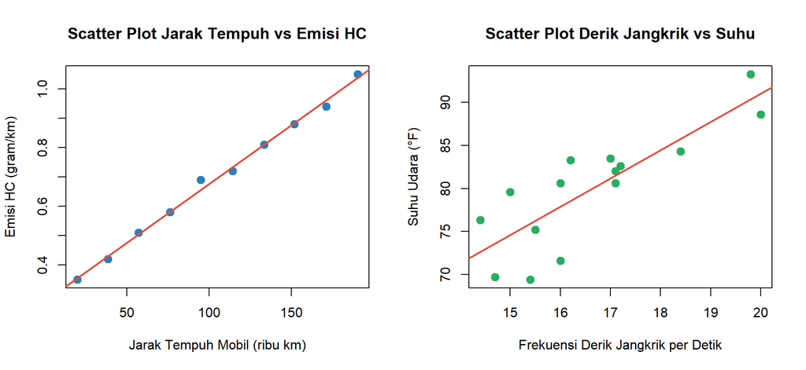

Figure 2.1: Diagram pencar (scatter plot) dan kecenderungan linier pada kasus Emisi HC Mobil (kiri) serta Derik Jangkrik vs Suhu Udara (kanan).

```r
# Langkah 1: Membaca kedua dataset korelasi
df_hc       <- read.csv("../data/10_emisi_hc_korelasi.csv")
df_jangkrik <- read.csv("../data/11_jangkrik_suhu.csv")

# Langkah 2: Visualisasi Scatter Plot berdampingan sebagai pemeriksaan pola linier
par(mfrow = c(1, 2))
plot(df_hc$Jarak_Tempuh_X, df_hc$Emisi_HC_Normal,
     pch = 19, col = "#2980b9", cex = 1.3,
     xlab = "Jarak Tempuh Mobil (ribu km)", ylab = "Emisi HC (gram/km)",
     main = "Scatter Plot Jarak Tempuh vs Emisi HC")
abline(lm(Emisi_HC_Normal ~ Jarak_Tempuh_X, data = df_hc), col = "#e74c3c", lwd = 2)

plot(df_jangkrik$Derik_Per_Detik, df_jangkrik$Suhu_Fahrenheit,
     pch = 19, col = "#27ae60", cex = 1.3,
     xlab = "Frekuensi Derik Jangkrik per Detik", ylab = "Suhu Udara (°F)",
     main = "Scatter Plot Derik Jangkrik vs Suhu")
abline(lm(Suhu_Fahrenheit ~ Derik_Per_Detik, data = df_jangkrik), col = "#e74c3c", lwd = 2)
```

```r
par(mfrow = c(1, 1))

# Langkah 3: Uji Korelasi Pearson Kasus 1 (Jarak Tempuh vs Emisi HC Normal)
cor.test(df_hc$Jarak_Tempuh_X, df_hc$Emisi_HC_Normal, method = "pearson")
```

```
#>
#>  Pearson's product-moment correlation
#>
#> data:  df_hc$Jarak_Tempuh_X and df_hc$Emisi_HC_Normal
#> t = 42.824, df = 8, p-value = 9.748e-11
#> alternative hypothesis: true correlation is not equal to 0
#> 95 percent confidence interval:
#>  0.9904697 0.9995055
#> sample estimates:
#>      cor
#> 0.997826
```

```r
# Langkah 4: Uji Korelasi Pearson Kasus 2 (Derik Jangkrik vs Suhu Udara)
cor.test(df_jangkrik$Derik_Per_Detik, df_jangkrik$Suhu_Fahrenheit, method = "pearson")
```

```
#>
#>  Pearson's product-moment correlation
#>
#> data:  df_jangkrik$Derik_Per_Detik and df_jangkrik$Suhu_Fahrenheit
#> t = 5.4745, df = 13, p-value = 0.0001067
#> alternative hypothesis: true correlation is not equal to 0
#> 95 percent confidence interval:
#>  0.5642928 0.9436856
#> sample estimates:
#>       cor
#> 0.8351438
```

```r
# Langkah 5: Pembuktian manual rumus t_hitung pada Kasus Jangkrik
n_j   <- nrow(df_jangkrik)
r_j   <- cor(df_jangkrik$Derik_Per_Detik, df_jangkrik$Suhu_Fahrenheit)
t_man <- r_j * sqrt(n_j - 2) / sqrt(1 - r_j^2)
cat(sprintf("Verifikasi Manual: r = %.4f | t_hitung = %.4f | db = %d\n", r_j, t_man, n_j - 2))
```

```
#> Verifikasi Manual: r = 0.8351 | t_hitung = 5.4745 | db = 13
```

## 2.5 Cara Membaca Output R & Kesimpulan Kasus

**Panduan Membaca Output `cor.test(..., method = "pearson")`:**

1. **Kasus 1 — Jarak Tempuh vs Emisi HC Normal ($n = 10$, `df = 8`)**:
   - Nilai penduga korelasi pada `sample estimates: cor` adalah **`0.9978`** (mendekati $+1,00$, hubungan positif sangat erat).
   - Nilai **`t = 42.824`** dengan **`p-value = 9.748e-11`** ($< 0,001$) serta selang kepercayaan 95% bagi $\rho$ adalah **`[0.9905, 0.9995]`** (tidak memuat angka nol). Tolak $H_0$: semakin jauh jarak tempuh kumulatif mobil, semakin tinggi emisi gas HC secara linier.
2. **Kasus 2 — Derik Jangkrik vs Suhu Udara ($n = 15$, `df = 13`)**:
   - Nilai **`cor = 0.8351`** menunjukkan keeratan hubungan positif yang kuat antara aktivitas metabolisme akustik jangkrik dan suhu udara.
   - Nilai **`t = 5.4745`** (sama persis dengan perhitungan rumus manual!) dan **`p-value = 0.0001067`** ($< 0,01$), dengan selang kepercayaan 95% **`[0.5643, 0.9437]`**.

**Kalimat Kesimpulan Siap Kutip (Kasus Derik Jangkrik):** > *“Hasil analisis korelasi linier Pearson menunjukkan terdapat hubungan positif yang kuat dan sangat nyata antara frekuensi derik jangkrik per detik dengan suhu udara lingkungan ($r = 0,8351$; $t_{\text{hitung}} = 5,4745$; $\text{db} = 13$; $p\text{-value} = 0,00011 < 0,01$; $\text{SK}_{95\%}: [0,5643;\; 0,9437]$).”*

# 3 Analisis 5.2: Uji Hipotesis Korelasi Umum ($H_0: \rho = \rho_0$) dengan Transformasi $Z$ Fisher

## 3.1 Penjelasan Awal (Konsep Dasar)

**Konsep Dasar — Mengapa Uji-$t$ Tidak Berlaku Saat Menguji $H_0: \rho = 0,70$?**

Fungsi `cor.test()` bawaan R **hanya menguji hipotesis nol $H_0: \rho = 0$**. Ketika nilai korelasi populasi yang dihipotesiskan bukan nol ($\rho_0 \neq 0$, misalnya $\rho_0 = 0,70$), sebaran penarikan contoh dari $r$ menjadi **sangat menjulur/miring (*skewed*)** karena nilai $r$ terbentur batas atas $+1,00$!

Untuk menormalkan sebaran yang miring tersebut, R.A. Fisher merumuskan **Transformasi $Z$ Fisher** menggunakan fungsi tangen hiperbolik balik ($\text{atanh}$), yang mengubah $r$ menjadi peubah $Z_r$ yang menyebar mendekati **Normal dengan ragam konstan $\frac{1}{n - 3}$**!

## 3.2 Konteks Kasus & Kapan Menggunakan Analisis Ini

**Studi Kasus: Pengujian Klaim Literatur $\rho_0 = 0,70$:**

- **Kapan Digunakan?** Gunakan **Transformasi $Z$ Fisher** apabila Anda ingin: (1) menguji apakah koefisien korelasi populasi sama dengan suatu patokan standar tertentu yang bukan nol ($H_0: \rho = \rho_0$), atau (2) menghitung selang kepercayaan bagi $\rho$ secara manual.
- **Skenario Penelitian**: Literatur terdahulu menyatakan bahwa korelasi antara frekuensi derik jangkrik dan suhu udara di alam adalah sebesar $\rho_0 = 0,70$. Berdasarkan sampel $n = 15$ pengamatan kita yang menghasilkan $r = 0,8351$, apakah korelasi populasi kita berbeda nyata dari klaim $0,70$ tersebut pada $\alpha = 5\%$?

## 3.3 Rumus Transformasi $Z$ Fisher & Hipotesis

Transformasi logaritma natural Fisher untuk korelasi sampel $r$ dan nilai hipotesis $\rho_0$:

$$Z_r = \frac{1}{2} \ln\left(\frac{1 + r}{1 - r}\right) = \text{atanh}(r), \qquad Z_{\rho_0} = \frac{1}{2} \ln\left(\frac{1 + \rho_0}{1 - \rho_0}\right) = \text{atanh}(\rho_0)$$

Statistik uji $Z$ dan Selang Kepercayaan $(1 - \alpha)$ melalui transformasi balik $\tanh(\cdot)$:

$$Z_{\text{hitung}} = \frac{Z_r - Z_{\rho_0}}{\sqrt{\frac{1}{n - 3}}} \sim N(0, 1), \qquad \text{SK}_{(1-\alpha)}(\rho) = \tanh\!\left(Z_r \pm Z_{\alpha/2}\sqrt{\frac{1}{n - 3}}\right)$$

**Pasangan Hipotesis:**

- **$H_0 : \rho = 0,70$** (Korelasi populasi antara derik jangkrik dan suhu udara sama dengan $0,70$).
- **$H_1 : \rho \neq 0,70$** (Korelasi populasi berbeda dari $0,70$ — uji dua arah; atau $H_1 : \rho > 0,70$ untuk uji satu arah kanan).

## 3.4 Kode R Siap Pakai (Step-by-Step)

```r
# Langkah 1: Membangun fungsi kustom Uji Hipotesis Korelasi Umum (Transformasi Z Fisher)
uji_fisher_z <- function(x, y, rho_0 = 0.70, alpha = 0.05) {
  n       <- length(x)
  r       <- cor(x, y, method = "pearson")
  z_r     <- atanh(r)                 # Sama persis dengan 0.5 * log((1 + r)/(1 - r))
  z_0     <- atanh(rho_0)             # Nilai Z untuk rho_0
  se_z    <- sqrt(1 / (n - 3))        # Galat baku transformasi Z Fisher
  z_hit   <- (z_r - z_0) / se_z
  p_2arah <- 2 * (1 - pnorm(abs(z_hit)))
  p_kanan <- 1 - pnorm(z_hit)         # p-value satu arah (H1: rho > rho_0)

  # Menghitung Selang Kepercayaan 95% bagi rho melalui transformasi balik tanh()
  z_kritis <- qnorm(1 - alpha / 2)
  sk_bawah <- tanh(z_r - z_kritis * se_z)
  sk_atas  <- tanh(z_r + z_kritis * se_z)

  data.frame(
    n             = n,
    r_sampel      = round(r, 4),
    rho_0         = rho_0,
    Z_r           = round(z_r, 4),
    Z_rho0        = round(z_0, 4),
    Z_hitung      = round(z_hit, 4),
    p_value_2arah = round(p_2arah, 4),
    p_value_kanan = round(p_kanan, 4),
    SK95_Bawah    = round(sk_bawah, 4),
    SK95_Atas     = round(sk_atas, 4)
  )
}

# Langkah 2: Menerapkan fungsi pada data Derik Jangkrik vs Suhu untuk menguji H0: rho = 0.70
uji_fisher_z(df_jangkrik$Derik_Per_Detik, df_jangkrik$Suhu_Fahrenheit, rho_0 = 0.70)
```

```
#>    n r_sampel rho_0    Z_r Z_rho0 Z_hitung p_value_2arah p_value_kanan
#> 1 15   0.8351   0.7 1.2049 0.8673   1.1695        0.2422        0.1211
#>   SK95_Bawah SK95_Atas
#> 1     0.5643    0.9437
```

## 3.5 Cara Membaca Output R & Kesimpulan Kasus

**Panduan Membaca Output Transformasi $Z$ Fisher:**

1. **Nilai Transformasi**: Korelasi contoh `r_sampel = 0.8351` ditransformasikan menjadi `Z_r = 1.2049`, sedangkan nilai hipotesis `rho_0 = 0.70` menjadi `Z_rho0 = 0.8673` dengan galat baku $\sqrt{1 / (15 - 3)} = 0,2887$.
2. **Keputusan Statistik (`Z_hitung = 1.1695`)**:
   - Karena $|Z_{\text{hitung}}| = 1,1695 < Z_{0,025} = 1,96$ dan **`p_value_2arah = 0.2422 > 0.05`** (bahkan untuk uji satu arah `p_value_kanan = 0.1211 > 0.05`), maka **Gagal Menolak $H_0$ (Terima $H_0$)**!
   - Perhatikan pula `SK95_Bawah = 0.5643` dan `SK95_Atas = 0.9437` — angka ini **identik 100%** dengan selang kepercayaan yang dicetak `cor.test()` pada Analisis 5.1, dan karena nilai `0.70` berada di dalam rentang `[0.5643, 0.9437]`, klaim $\rho_0 = 0,70$ tidak ditolak!

**Kalimat Kesimpulan Siap Kutip:** > *“Berdasarkan uji Transformasi $Z$ Fisher pada taraf nyata $\alpha = 5\%$, diperoleh nilai $Z_{\text{hitung}} = 1,1695$ dengan $p\text{-value} = 0,2422 > 0,05$, sehingga gagal menolak $H_0$. Dengan demikian, belum terdapat cukup bukti untuk menyatakan bahwa korelasi populasi antara frekuensi derik jangkrik dan suhu udara berbeda dari $0,70$.”*

# 4 Analisis 5.3: Korelasi Peringkat Spearman (Data Ber-*Outlier* atau Skala Ordinal)

## 4.1 Penjelasan Awal (Konsep Dasar)

**Konsep Dasar — Mengapa Korelasi Spearman Kebal terhadap *Outlier*?**

Korelasi Pearson sangat peka terhadap **pencilan (*outlier*)**: satu titik ekstrem saja dapat merusak rata-rata $\bar{X}, \bar{Y}$ dan simpangan baku secara drastis. Sebaliknya, **Korelasi Peringkat Spearman ($r_s$)** bekerja dengan **mengubah seluruh nilai pengamatan menjadi nomor urut peringkat (*rank* $1, 2, \dots, n$)** terlebih dahulu, lalu menghitung korelasi antar-peringkat tersebut! Selama urutan peringkatnya tidak berubah, sebesar apa pun lonjakan angka pencilan tidak akan menggoyahkan nilai $r_s$.

## 4.2 Konteks Kasus & Kapan Menggunakan Analisis Ini

**Studi Kasus — Kerusakan Mesin Mobil ke-10 pada Data Emisi HC:**

Gunakan **Korelasi Spearman** ketika: 1. Data kuantitatif mengandung **pencilan ekstrem (*outlier*)** yang tidak dapat dibuang begitu saja. 2. Hubungan antar-peubah bersifat **monoton melengkung** (misal eksponensial/logaritmik: selalu naik tetapi bukan garis lurus). 3. Salah satu atau kedua peubah berskala **ordinal/skor** (misal skor keparahan penyakit daun $1\text{--}5$ vs skor ketahanan varietas).

**Skenario Kasus**: Pada dataset `data/10_emisi_hc_korelasi.csv`, kolom `Emisi_HC_Outlier` merepresentasikan kondisi ketika mobil ke-10 mengalami kebocoran katup pembakaran sehingga emisinya melonjak dari `1.05` menjadi **`2.35` gram/km**. Mari kita buktikan dampaknya pada Pearson vs Spearman!

## 4.3 Rumus Korelasi Peringkat Spearman & Hipotesis

Jika tidak terdapat peringkat kembar (*ties*), koefisien korelasi Spearman dihitung dari selisih peringkat $d_i = \text{Rank}(X_i) - \text{Rank}(Y_i)$:

$$r_s = 1 - \frac{6 \sum_{i=1}^n d_i^2}{n(n^2 - 1)}, \qquad -1 \le r_s \le +1$$

*(Apabila terdapat peringkat kembar, R secara otomatis menghitung korelasi Pearson pada vektor peringkat rata-rata).*

**Pasangan Hipotesis:**

- **$H_0 : \rho_s = 0$** (Tidak terdapat hubungan monoton antara peringkat $X$ dan peringkat $Y$).
- **$H_1 : \rho_s \neq 0$** (Terdapat hubungan monoton yang nyata antara $X$ dan $Y$).

## 4.4 Kode R Siap Pakai (Step-by-Step)

```r
# Langkah 1: Menghitung korelasi Pearson & Spearman pada data Normal vs data Ber-Outlier
r_pearson_normal   <- cor.test(df_hc$Jarak_Tempuh_X, df_hc$Emisi_HC_Normal, method = "pearson")
r_spearman_normal  <- cor.test(df_hc$Jarak_Tempuh_X, df_hc$Emisi_HC_Normal, method = "spearman", exact = FALSE)

r_pearson_outlier  <- cor.test(df_hc$Jarak_Tempuh_X, df_hc$Emisi_HC_Outlier, method = "pearson")
r_spearman_outlier <- cor.test(df_hc$Jarak_Tempuh_X, df_hc$Emisi_HC_Outlier, method = "spearman", exact = FALSE)

# Langkah 2: Menyusun tabel perbandingan langsung Pearson vs Spearman
perbandingan_korelasi <- data.frame(
  Kondisi_Data = c("Tanpa Outlier (Normal)", "Dengan 1 Outlier (Mobil ke-10 = 2.35)"),
  r_Pearson    = round(c(r_pearson_normal$estimate, r_pearson_outlier$estimate), 4),
  p_Pearson    = signif(c(r_pearson_normal$p.value, r_pearson_outlier$p.value), 4),
  r_Spearman   = round(c(r_spearman_normal$estimate, r_spearman_outlier$estimate), 4),
  p_Spearman   = signif(c(r_spearman_normal$p.value, r_spearman_outlier$p.value), 4)
)
print(perbandingan_korelasi)
```

```
#>                            Kondisi_Data r_Pearson p_Pearson r_Spearman
#> 1                Tanpa Outlier (Normal)    0.9978 9.748e-11          1
#> 2 Dengan 1 Outlier (Mobil ke-10 = 2.35)    0.7811 7.643e-03          1
#>   p_Spearman
#> 1  1.064e-62
#> 2  1.064e-62
```

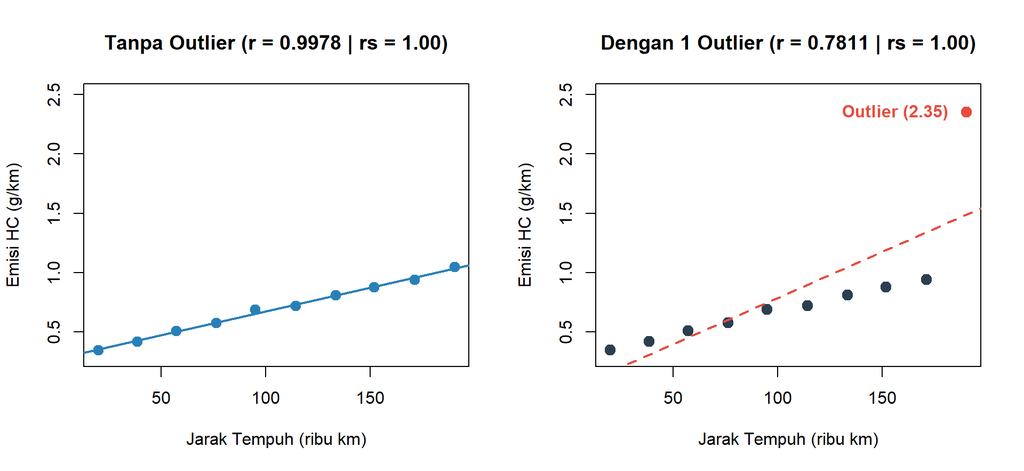

Figure 4.1: Perbandingan dampak satu pencilan ekstrem pada mobil ke-10 (titik merah): korelasi Pearson merosot tajam dari 0,9978 menjadi 0,7811, sedangkan korelasi Spearman tetap kokoh 1,0000.

```r
# Langkah 3: Visualisasi berdampingan tarikan pencilan terhadap garis linier
par(mfrow = c(1, 2))
plot(df_hc$Jarak_Tempuh_X, df_hc$Emisi_HC_Normal, pch = 19, col = "#2980b9", cex = 1.3,
     ylim = c(0.3, 2.5), xlab = "Jarak Tempuh (ribu km)", ylab = "Emisi HC (g/km)",
     main = "Tanpa Outlier (r = 0.9978 | rs = 1.00)")
abline(lm(Emisi_HC_Normal ~ Jarak_Tempuh_X, data = df_hc), col = "#2980b9", lwd = 2)

warna_titik <- ifelse(df_hc$Mobil == 10, "#e74c3c", "#2c3e50")
plot(df_hc$Jarak_Tempuh_X, df_hc$Emisi_HC_Outlier, pch = 19, col = warna_titik, cex = 1.4,
     ylim = c(0.3, 2.5), xlab = "Jarak Tempuh (ribu km)", ylab = "Emisi HC (g/km)",
     main = "Dengan 1 Outlier (r = 0.7811 | rs = 1.00)")
abline(lm(Emisi_HC_Outlier ~ Jarak_Tempuh_X, data = df_hc), col = "#e74c3c", lwd = 2, lty = 2)
text(df_hc$Jarak_Tempuh_X[10] - 34, df_hc$Emisi_HC_Outlier[10], "Outlier (2.35)", col = "#e74c3c", font = 2)
```

```r
par(mfrow = c(1, 1))
```

## 4.5 Cara Membaca Output R & Kesimpulan Kasus

**Bukti Nyata Kekekaran (*Robustness*) Korelasi Spearman:**

1. **Kejatuhan Korelasi Pearson**: Hanya gara-gara **satu amatan ekstrem** pada mobil ke-10 (`2.35` g/km), koefisien korelasi Pearson anjlok drastis dari **`0.9978`** menjadi **`0.7811`**, dan garis linier putus-putus merah terangkat menjauhi sembilan titik pengamatan lainnya!
2. **Ketangguhan Korelasi Spearman (`rho = 1`)**: Baik sebelum maupun sesudah terjadi lonjakan angka `2.35`, mobil ke-10 tetap menempati peringkat ke-10 pada jarak tempuh sekaligus peringkat ke-10 pada emisi HC ($d_i = 0$ untuk seluruh $i = 1 \dots 10$), sehingga nilai **`r_Spearman = 1.0000` (`p < 2.2e-16`)** sama sekali tidak terusik!

**Kalimat Kesimpulan Siap Kutip:** > *“Pada data emisi gas buang yang mengandung pencilan ekstrem di amatan ke-10, koefisien korelasi Pearson mengalami distorsi penurunan dari $0,9978$ menjadi $0,7811$, sedangkan analisis korelasi peringkat Spearman tetap kekar menunjukkan hubungan monoton positif sempurna ($r_s = 1,0000$; $p < 2,2 \times 10^{-16}$).”*

# 5 Analisis 5.4: Tabel Kontingensi & Uji Khi-Kuadrat ($\chi^2$) untuk Dua Peubah Kategorik

## 5.1 Penjelasan Awal (Konsep Dasar)

**Konsep Dasar — Menguji Kebebasan Dua Peubah Kategorik:**

Apabila kedua peubah bersifat **kualitatif/kategorik** (sehingga tidak memiliki angka rata-rata ataupun peringkat kontinu), pengamatan diringkas menjadi frekuensi cacahan sel di dalam **Tabel Kontingensi $b \times k$** ($b$ baris $\times$ $k$ kolom). **Uji Khi-Kuadrat ($\chi^2$)** bekerja dengan membandingkan **Frekuensi Teramati ($O_{ij}$)** di lapangan terhadap **Frekuensi Harapan ($E_{ij}$)** yang seharusnya terjadi andaikata kedua peubah sama sekali tidak berhubungan (*independen*). Semakin besar selisih $(O_{ij} - E_{ij})^2$, semakin kuat bukti adanya keterkaitan antar-kedua peubah!

## 5.2 Konteks Kasus & Kapan Menggunakan Analisis Ini

**Studi Kasus: Sosial-Ekonomi Pertanian:**

- **Kapan Digunakan?** Gunakan **Tabel Kontingensi & Uji Khi-Kuadrat** ketika peubah $X$ dan $Y$ keduanya merupakan kategori kualitatif, dengan syarat **seluruh frekuensi harapan $E_{ij} \ge 5$** (jika pada tabel $2 \times 2$ ada $E_{ij} < 5$, gunakan alternatif `fisher.test()`).
- **Skenario Penelitian**: Survei penyuluhan pertanian terhadap $N = 110$ petani padi mengkaji apakah terdapat asosiasi antara **Status Penguasaan Lahan** (`Sewa/Sakap` vs `Milik_Sendiri`) dengan **Tingkat Adopsi Benih Varietas Unggul Baru** (`Rendah`, `Sedang`, `Tinggi`).

## 5.3 Rumus Statistik Uji Khi-Kuadrat ($\chi^2$), Koefisien Asosiasi, & Hipotesis

Frekuensi harapan pada sel baris ke-$i$ kolom ke-$j$ di bawah asumsi kebebasan adalah:

$$E_{ij} = \frac{(\text{Total Baris ke-}i) \times (\text{Total Kolom ke-}j)}{\text{Total Seluruh Sampel } (N)}$$

Statistik uji Khi-Kuadrat Pearson dan ukuran keeratan **Cramér’s $V$**:

$$\chi^2_{\text{hitung}} = \sum_{i=1}^b \sum_{j=1}^k \frac{(O_{ij} - E_{ij})^2}{E_{ij}} \sim \chi^2_{((b - 1)(k - 1))}, \qquad V = \sqrt{\frac{\chi^2_{\text{hitung}}}{N \cdot \min(b - 1,\; k - 1)}}$$

**Pasangan Hipotesis:**

- **$H_0$**: Status penguasaan lahan dan tingkat adopsi benih unggul **saling bebas** (tidak terdapat asosiasi).
- **$H_1$**: Terdapat **asosiasi (keterkaitan) nyata** antara status penguasaan lahan dan tingkat adopsi benih unggul.

## 5.4 Kode R Siap Pakai (Step-by-Step)

```r
# Langkah 1: Menyusun matriks Tabel Kontingensi 2 x 3 beserta label baris dan kolom
tabel_adopsi <- matrix(
  c(28, 15,  7,
    12, 25, 23),
  nrow = 2, byrow = TRUE,
  dimnames = list(
    Status_Lahan = c("Sewa/Sakap", "Milik_Sendiri"),
    Adopsi_Benih = c("Rendah", "Sedang", "Tinggi")
  )
)

# Menampilkan tabel frekuensi teramati (O_ij) lengkap dengan total baris & kolom
addmargins(tabel_adopsi)
```

```
#>                Adopsi_Benih
#> Status_Lahan    Rendah Sedang Tinggi Sum
#>   Sewa/Sakap        28     15      7  50
#>   Milik_Sendiri     12     25     23  60
#>   Sum               40     40     30 110
```

```r
# Langkah 2: Menjalankan Uji Khi-Kuadrat Independensi
uji_chi <- chisq.test(tabel_adopsi)
print(uji_chi)
```

```
#>
#>  Pearson's Chi-squared test
#>
#> data:  tabel_adopsi
#> X-squared = 16.662, df = 2, p-value = 0.0002409
```

```r
# Langkah 3: Memeriksa syarat validitas frekuensi harapan (seluruh sel wajib E_ij >= 5)
round(uji_chi$expected, 2)
```

```
#>                Adopsi_Benih
#> Status_Lahan    Rendah Sedang Tinggi
#>   Sewa/Sakap     18.18  18.18  13.64
#>   Milik_Sendiri  21.82  21.82  16.36
```

```r
# Langkah 4: Menghitung Koefisien Kontingensi (C) dan Cramer's V
N_tot     <- sum(tabel_adopsi)
koef_C    <- sqrt(uji_chi$statistic / (uji_chi$statistic + N_tot))
cramers_V <- sqrt(uji_chi$statistic / (N_tot * (min(dim(tabel_adopsi)) - 1)))
cat(sprintf("Koefisien Kontingensi C = %.4f | Cramer's V = %.4f\n", koef_C, cramers_V))
```

```
#> Koefisien Kontingensi C = 0.3627 | Cramer's V = 0.3892
```

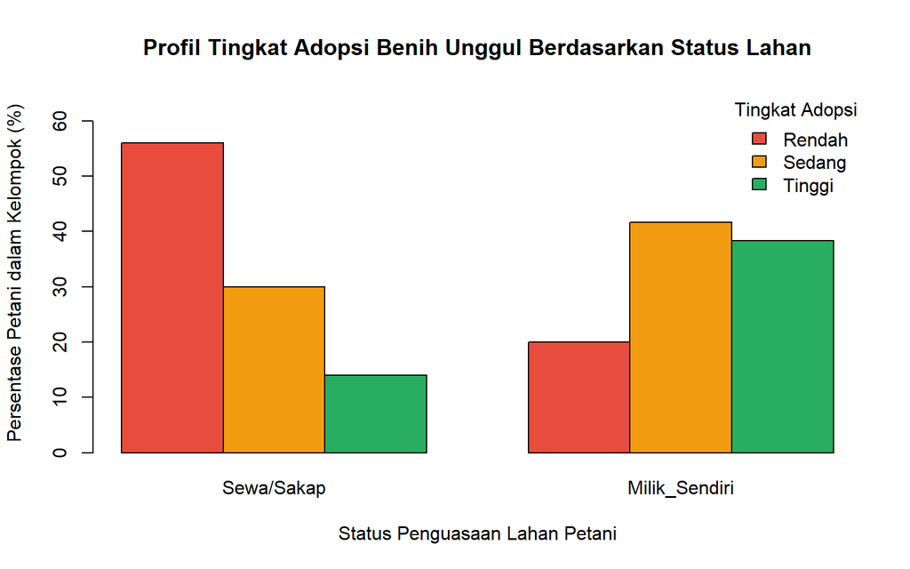

Figure 5.1: Distribusi persentase tingkat adopsi benih unggul pada kelompok petani penyewa/penyakap dibandingkan petani pemilik lahan sendiri.

```r
# Langkah 5: Visualisasi profil persentase adopsi per status penguasaan lahan
prop_adopsi <- prop.table(tabel_adopsi, margin = 1) * 100
barplot(t(prop_adopsi), beside = TRUE,
        col = c("#e74c3c", "#f39c12", "#27ae60"), ylim = c(0, 65),
        xlab = "Status Penguasaan Lahan Petani",
        ylab = "Persentase Petani dalam Kelompok (%)",
        main = "Profil Tingkat Adopsi Benih Unggul Berdasarkan Status Lahan")
legend("topright", legend = colnames(tabel_adopsi),
       fill = c("#e74c3c", "#f39c12", "#27ae60"), title = "Tingkat Adopsi", bty = "n")
```

## 5.5 Cara Membaca Output R & Kesimpulan Kasus

**Panduan Membaca Output `chisq.test(tabel_adopsi)`:**

1. **Pemeriksaan Syarat Validitas (`uji_chi$expected`)**: Seluruh 6 sel memiliki nilai harapan antara `13.64` hingga `21.82` (semuanya $\ge 5$), sehingga pendekatan sebaran Khi-Kuadrat 100% sah digunakan.
2. **Keputusan Uji Statistik**:
   - Diperoleh **`X-squared = 16.662`** pada derajat bebas **`df = 2`** ($(2 - 1)(3 - 1) = 2$) dengan **`p-value = 0.0002409`** ($< 0,01$).
   - Karena `p-value < 0.05`, maka **Tolak $H_0$**! Terdapat hubungan asosiasi yang sangat nyata dengan kekuatan moderat (`Cramer's V = 0.3892`).
3. **Arah Pola Asosiasi (dari Grafik Persentase)**: Mayoritas petani `Sewa/Sakap` terkonsentrasi pada tingkat adopsi **Rendah ($56,0\%$)**, sedangkan mayoritas petani `Milik_Sendiri` berada pada tingkat adopsi **Sedang ($41,7\%$) dan Tinggi ($38,3\%$)**.

**Kalimat Kesimpulan Siap Kutip:** > *“Hasil Uji Khi-Kuadrat pada tabel kontingensi menunjukkan terdapat asosiasi yang sangat nyata antara status penguasaan lahan petani dan tingkat adopsi benih unggul ($\chi^2_{\text{hitung}} = 16,662$; $\text{db} = 2$; $p\text{-value} = 0,00024 < 0,01$; $\text{Cramér's } V = 0,3892$), di mana petani pemilik lahan sendiri memiliki kecenderungan adopsi teknologi sedang hingga tinggi ($80,0\%$) yang jauh lebih besar dibandingkan petani penyewa/penyakap ($44,0\%$).”*